# Applied Computational Methods for Social Sciences

Lecture 12: Geometric Operations with Vectors — Spatial Joins and Centroids

Bogdan G. Popescu

bogdan.popescu@johncabot.edu

John Cabot University

## What You’ll Learn Today

1. Mapping **wildfire points** over country polygons
2. **Animating** points on a map over time
3. Calculating **polygon centroids**
4. **Spatial joins** with `st_join`: matching, aggregating, and sharing attributes by location
5. Interactive maps with **leaflet**

By the end, you’ll be able to combine layers by location, not just by key.

## Intro

The main goals for the include:

- Further familiarize ourselves with vector layers: points, lines, and polygons
- Examine spatial and non-spatial properties of vector layers
- Create subsets of vector layers based on their attributes

## Specifics:

We will again make use to the `sf` package:

- join data to a vector by location
- agregate points by polygon

## Join by Location

We will work with wildfires data to demonstrate the principles of join by location

Spain is one of the countries worst affected by wildfires in recent times.

We try to match provinces with fires.

## Just August of 2021

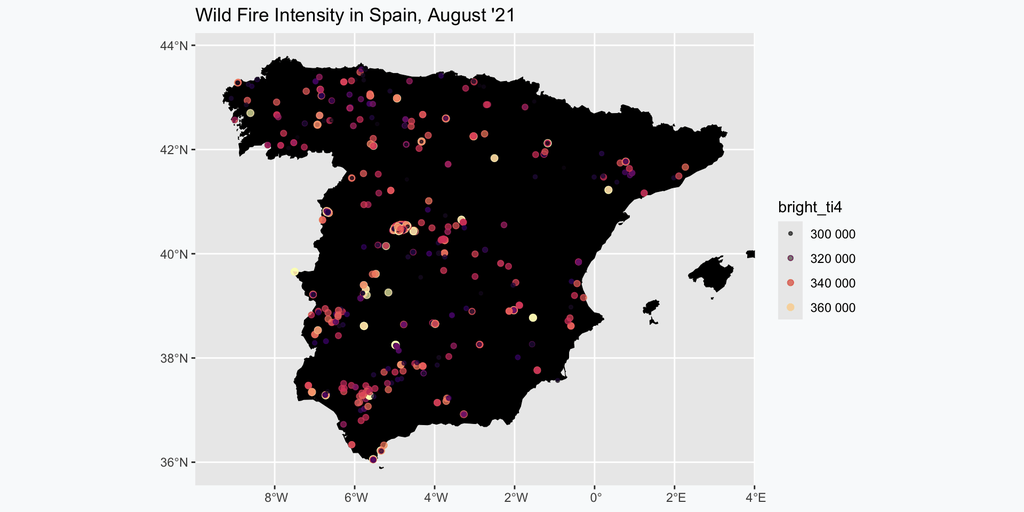

## Data

To obtain this, we need to collect some data

First, go to https://gadm.org and download the shapefiles for Spain

Second, obtain wildfire data from the NASA website: https://firms.modaps.eosdis.nasa.gov

## Data: `irms.modaps.eosdis.nasa.gov`

[figure not shown]

## Data: `irms.modaps.eosdis.nasa.gov`

[figure not shown]

## Data: `irms.modaps.eosdis.nasa.gov`

[figure not shown]

## Data: `irms.modaps.eosdis.nasa.gov`

[figure not shown]

## Data: `irms.modaps.eosdis.nasa.gov`

[figure not shown]

## Data: `irms.modaps.eosdis.nasa.gov`

[figure not shown]

## Data: `irms.modaps.eosdis.nasa.gov`

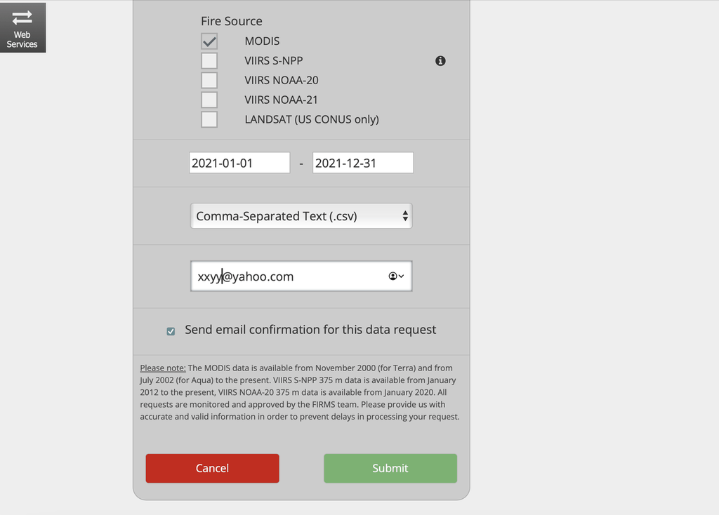

## Data: `irms.modaps.eosdis.nasa.gov`

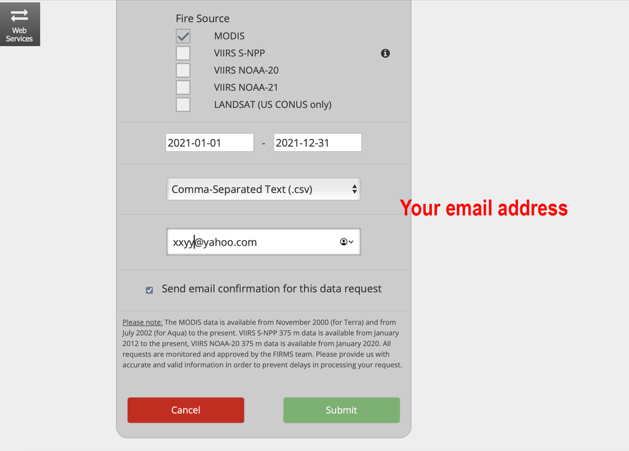

## Data: `irms.modaps.eosdis.nasa.gov`

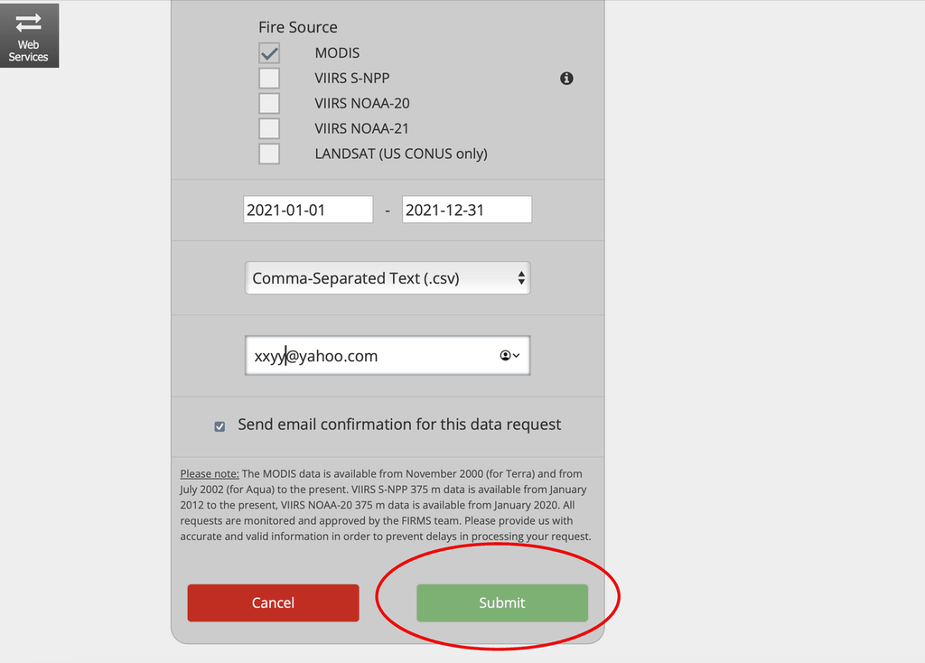

## Data: `irms.modaps.eosdis.nasa.gov`

[figure not shown]

## Data: `irms.modaps.eosdis.nasa.gov`

After you submit your request, you will get an automatic email.

It will tell you that the request is being processed.

At some point, you will get a notification that the your request has been processed.

You should go though all the above mentioned steps if you’re interested in this topic for your final project.

## Data: `irms.modaps.eosdis.nasa.gov`

To save time, you can [download the wildfires for Spain in 2021](https://www.dropbox.com/scl/fi/6vjgn8pe41ozrvgxemwlz/viirs-snpp_2021_Spain.csv?rlkey=s0lgja9f7mgkodhsniadhv7m7&dl=0)

Also, refer to the the model research project for this class

- [Memo](https://bgpopescu.net/files/teaching/big_data/example/memo_example.html)
- [Presentation](https://bgpopescu.net/files/teaching/big_data/example/memo_example_presentation#/the-getis-ord-gi-statistic)

## Figure

Reminder: we want to obtain the following figure

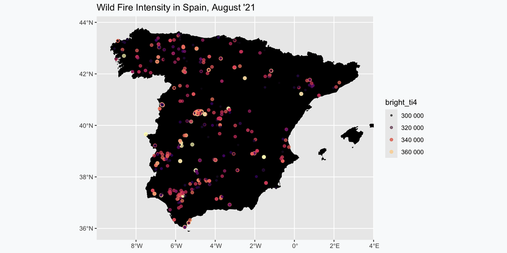

## Steps to obtain the figure

We will first process the shapefile for Spain.

Notice that Spain’s territory is larger than the common territory that we associate with Spain.

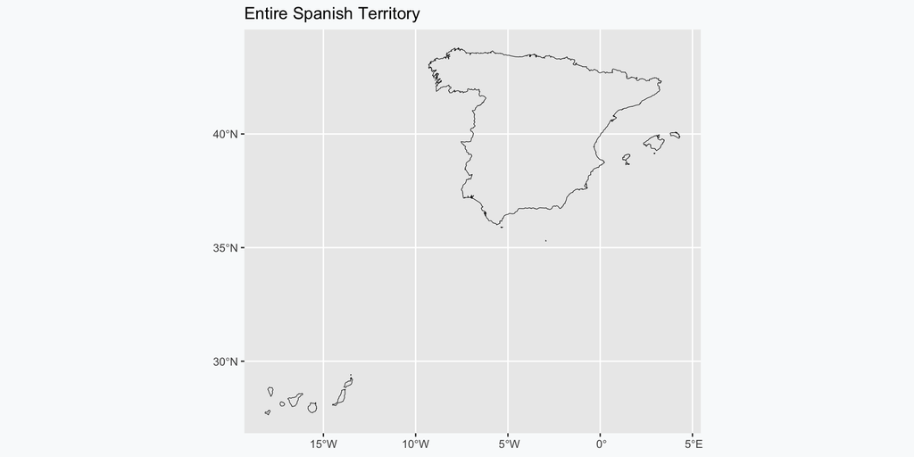

```r
ggplot()+
  geom_sf(data=esp0, color="black", fill=NA)+
  ggtitle("Entire Spanish Territory")
```

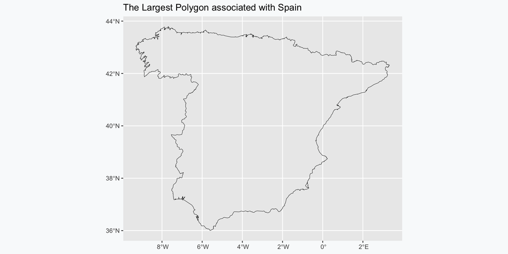

```r
ggplot()+
  geom_sf(data=esp0c, color="black", fill=NA)+
  ggtitle("The Largest Polygon associated with Spain")
```

## Steps to obtain the figure

Here is how we select the largest polygon associated with Spain

```r
#Step1: Loading libraries
library(sf)
library(ggplot2)
#Step2: Turn "s2" off to enable polygon simplification
sf_use_s2(FALSE)

#Step3: Reading Spain borders
esp0 <- st_read(dsn="./data/gadm41_ESP_shp/gadm41_ESP_0.shp", quiet = TRUE)
esp0<-st_simplify(esp0, dTolerance=0.01)

#Note: Spain is made out of the polygons
#We will focus on the largest polygons
#that are traditionally associated with Spain

#Step4: Turning multipolygons into polygons
esp0b = st_cast(esp0,"POLYGON")

#Step5: Calculating polygon area
esp0b$area<-st_area(esp0b)

#Step6: Turning the units into square km
esp0b$area2<-units::set_units(esp0b$area, km^2)

#Step7: Only choosing the largest polygon
esp0c<-subset(esp0b, area2==max(esp0b$area2))
```

## Steps to obtain the figure

```r
#Step8: Making a box object around the polygon
bbox <- st_bbox(esp0c)

#Step9: Extracting min and max latitudes and longitudes
min_lat_y <- bbox["ymin"]
max_lat_y <- bbox["ymax"]
min_lon_x <- bbox["xmin"]
max_lon_x <- bbox["xmax"]
```

## Steps to obtain the figure

Here is how `esp0` differs from `esp0c`

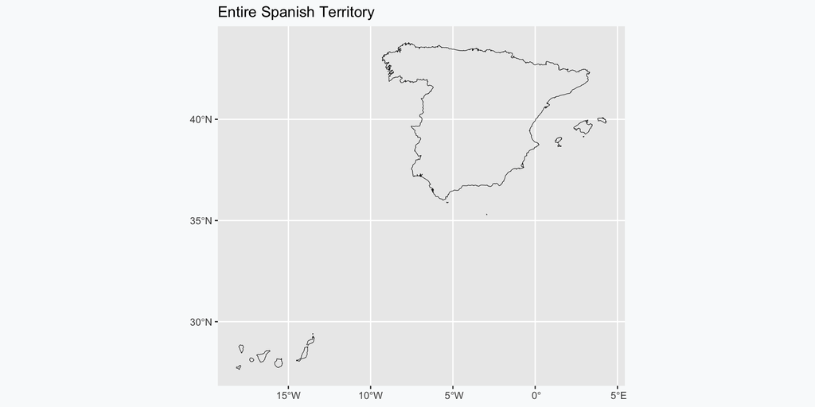

```r
ggplot()+
  geom_sf(data=esp0, color="black", fill=NA)+
  ggtitle("Entire Spanish Territory")
```

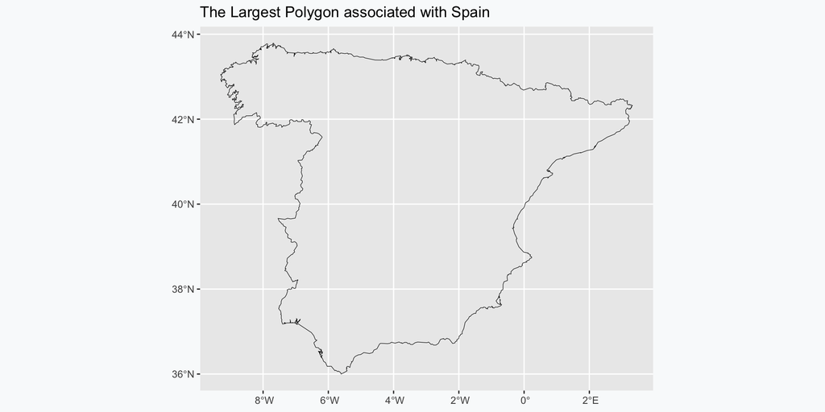

```r
ggplot()+
  geom_sf(data=esp0c, color="black", fill=NA)+
  ggtitle("The Largest Polygon associated with Spain")
```

## Steps to obtain the figure

We will now process the fires data

```r
#Step1: Reading wildfires
fires <- read.csv('./data/fires_2021/viirs-snpp_2021_Spain.csv')
#Step2: Turning the relevant time variable into a date variable recognized by R
fires$acq_date<-as.Date(fires$acq_date)
#Step3: Turning the CSV file into an SF object
fires_sf<-st_as_sf(fires, coords = c("longitude", "latitude"))
#Step4: Associating the crs information for the Spain shapefile to points
fires_sf <- st_set_crs(fires_sf, st_crs(esp0))  # 4326 is the EPSG code for WGS84
#Step5: Only selecting fires of type 0
#See the variable definitions:
#0 = presumed vegetation fire
#1 = active volcano
#2 = other static land source
#3 = offshore detection (includes all detections over water)
fires_sf<-subset(fires_sf, type==0)
#Step6: Extract month information
fires_sf$month <- format(fires_sf$acq_date, "%m")
#Step7: Reading only August
fires_aug<-subset(fires_sf, acq_date>"2021-07-31" & acq_date<"2021-09-01")
```

To learn about what the different variables associated with the fires, visit: https://www.earthdata.nasa.gov/learn/find-data/near-real-time/firms/vnp14imgtdlnrt#ed-viirs-375m-attributes

## Making the map

We can finally make the map:

```r
#Defining an error for better map extent
error<-0.05
ggplot() +
  geom_sf(data = esp0, color = "black", fill="black") +
  geom_sf(data = fires_aug, aes(color = bright_ti4, size = bright_ti4), alpha = 0.7) +
  scale_color_viridis_c(option = "A", name = "bright_ti4")+
  scale_size_continuous(range = c(0.5, 2),
                        name = "bright_ti4") +
  #We still need to define the extent: fires also happen outside the large polygon
  #associated with Spain
  coord_sf(xlim = c(min_lon_x - error, max_lon_x + error),
           ylim = c(min_lat_y - error, max_lat_y + error)) +
  ggtitle("Wild Fire Intensity in Spain, August '21") +
  guides(color = guide_legend(title.position = "top"),
    size = guide_legend(title.position = "top"))
```

## Making the map

We can finally make the map:

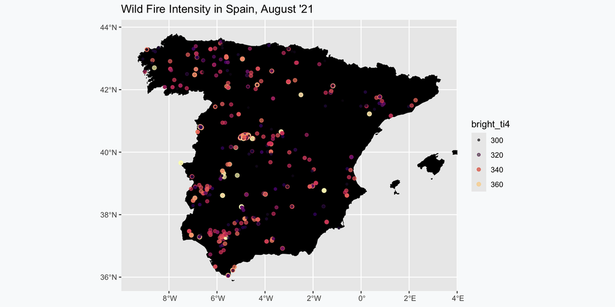

## Entire Year

We can also produce the following map

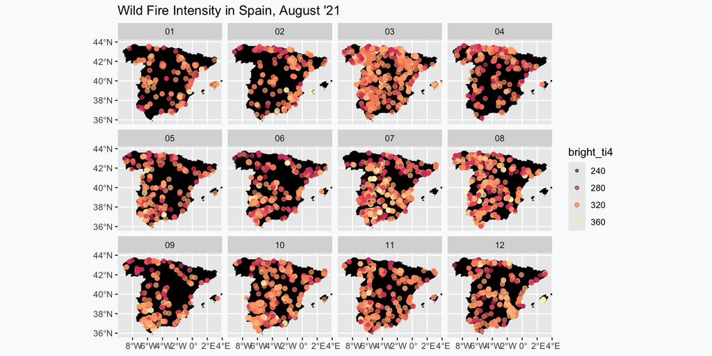

## Entire Year

This is done using `facet_wrap`

```r
ggplot() +
  geom_sf(data = esp0, color = "black", fill="black") +
  geom_sf(data = fires_sf, aes(color = bright_ti4, size = bright_ti4), alpha = 0.7) +
  scale_color_viridis_c(option = "A", name = "bright_ti4")+
  scale_size_continuous(range = c(0.5, 2),
                        name = "bright_ti4") +
  coord_sf(xlim = c(min_lon_x - error, max_lon_x + error),
           ylim = c(min_lat_y - error, max_lat_y + error)) +
  ggtitle("Wild Fire Intensity in Spain, August '21") +
  guides(color = guide_legend(title.position = "top"),
  size = guide_legend(title.position = "top"))+
    facet_wrap(~month, ncol = 4)  # Adjust the number of columns as needed
```

## Entire Year

This is done using `facet_wrap`

```r
ggplot() +
  geom_sf(data = esp0, color = "black", fill="black") +
  geom_sf(data = fires_sf, aes(color = bright_ti4, size = bright_ti4), alpha = 0.7) +
  scale_color_viridis_c(option = "A", name = "bright_ti4")+
  scale_size_continuous(range = c(0.5, 2),
                        name = "bright_ti4") +
  coord_sf(xlim = c(min_lon_x - error, max_lon_x + error),
           ylim = c(min_lat_y - error, max_lat_y + error)) +
  ggtitle("Wild Fire Intensity in Spain, August '21") +
  guides(color = guide_legend(title.position = "top"),
  size = guide_legend(title.position = "top"))+
    facet_wrap(~month, ncol = 4)  # Adjust the number of columns as needed
```

## Entire Year

Or we can produce an animated map:

[figure not shown]

## Entire Year

Or we can produce an animated map:

```r
library("gganimate")
#Extracting coordinates
fires_sf$lat_x<-st_coordinates(fires_sf)[,"X"]
fires_sf$lon_y<-st_coordinates(fires_sf)[,"Y"]
#Dropping the geometry
fires<-st_drop_geometry(fires_sf)

#Mapping
fig<-ggplot() +
  geom_sf(data = esp0, color = "black", fill="black")+
  #We need to use geom_point NOT geom_sf because of library compatibility problems
  geom_point(data = fires, aes(x= lat_x, y = lon_y,
                               color = bright_ti4, size = bright_ti4), alpha = 0.9)+
  #Note that animated geom_sf with points does not work because of some library incompatibility
  #geom_sf(data = fires_sf, aes(color = bright_ti4, size = bright_ti4), alpha = 0.7) +
  scale_color_viridis_c(option = "A", name = "bright_ti4")+
  scale_size_continuous(range = c(0.1, 4),
                        name = "bright_ti4") +
  guides(color = guide_legend(title = "bright_ti4"),
         size = guide_legend(title = "bright_ti4"))+
  coord_sf(xlim = c(min_lon_x - error, max_lon_x + error),
           ylim = c(min_lat_y - error, max_lat_y + error))+
  #animate arguments
  transition_time(acq_date) +
  ggtitle('Date: {frame_time}')
#defining animation options: speed of transition and resolution
animate(fig, fps=2, res = 60)
```

## Spatial Join

- `spatial join` is one of the most common operations in spatial analysis.
- In a spatial join we are “attaching” attributes from one layer to another, based on their spatial relations.
- For example, we will match the fires to Spanish provinces.

## Spatial Join: Count by Polygon

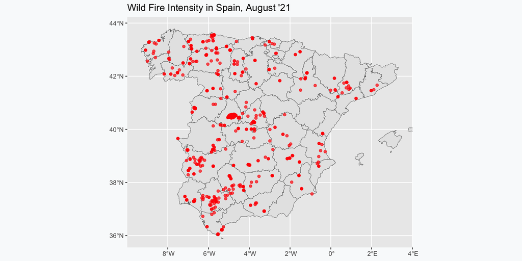

## Spatial Join: Count by Polygon

Place the folder with the shape files in the relevant week folder

Do the same for wildfires

This is how we read the shapefiles for Spain

```r
sf_use_s2(FALSE)
library(sf)
library(ggplot2)
#Reading Spain borders
esp0 <- st_read(dsn="./data/gadm41_ESP_shp/gadm41_ESP_0.shp", quiet = TRUE)
esp0<-st_simplify(esp0, dTolerance=0.5)

esp2 <- st_read(dsn="./data/gadm41_ESP_shp/gadm41_ESP_2.shp", quiet = TRUE)
esp2<-st_simplify(esp2, dTolerance=0.01)

esp3 <- st_read(dsn="./data/gadm41_ESP_shp/gadm41_ESP_3.shp", quiet = TRUE)
esp3<-st_simplify(esp3, dTolerance=0.5)
```

## Spatial Join: Count by Polygon

And this is how we read the wildfires:

```r
#Step1: Reading wildfires
fires <- read.csv('./data/fires_2021/viirs-snpp_2021_Spain.csv')
#Step2: Turning the acq_date variable into a date variable
fires$acq_date<-as.Date(fires$acq_date)
#Step3: Make sf object from points
fires<-st_as_sf(fires, coords = c("longitude", "latitude"))
fires <- st_set_crs(fires, st_crs(esp0))  # 4326 is the EPSG code for WGS84
#Step4: Extract month and year information
fires$month <- format(fires$acq_date, "%m")
fires$year <- format(fires$acq_date, "%Y")
#Step5: Simplifying our data
fires<-subset(fires, type==0)
#Step6: Reading only August
fires_aug<-subset(fires, acq_date>"2021-07-31" & acq_date<"2021-09-01")
```

## Spatial Join: Count by Polygon

We will try to count the number of fires by province

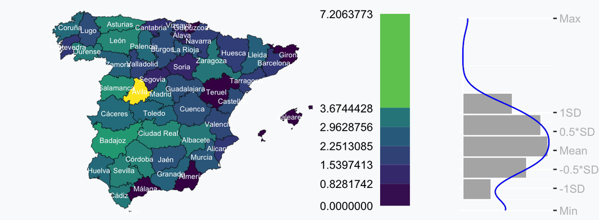

## Original Data Comparison

And this is how it differs from the original data: note the many overlapping points

Jittering the points allows us to see better the ones that are clustered

**Show the code - Low Jitter**

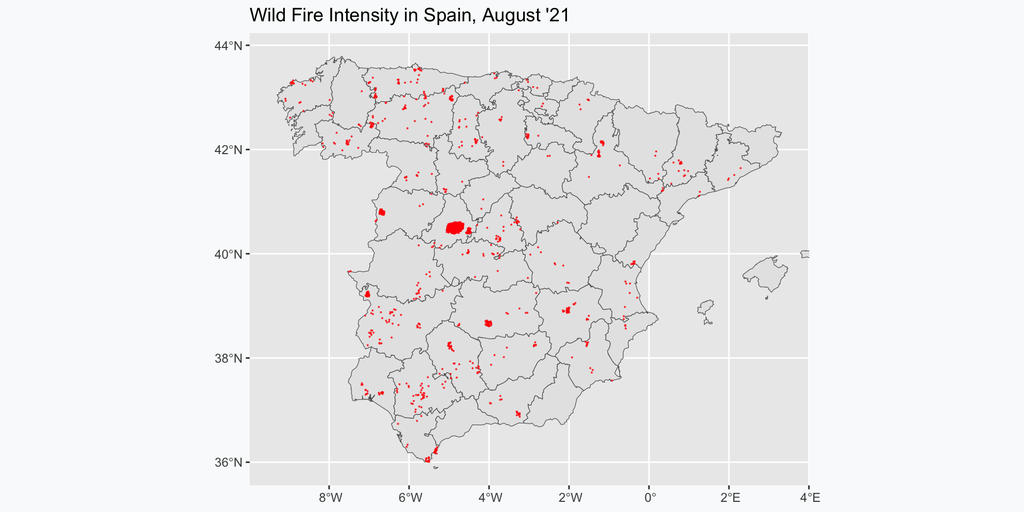

```r
error<-0.05
ggplot() +
  geom_sf(data = esp2b) +
  #low jitter
  geom_sf(data = st_jitter(fires_augb, 0.05),
          size=0.05, color = "red", alpha = 0.7) +
  coord_sf(xlim = c(min_lon_x - error, max_lon_x + error),
           ylim = c(min_lat_y - error, max_lat_y + error)) +
  ggtitle("Wild Fire Intensity in Spain, August '21") +
  guides(
    color = guide_legend(title.position = "top"),
    size = guide_legend(title.position = "top")
  )
```

**Show the code - High Jitter**

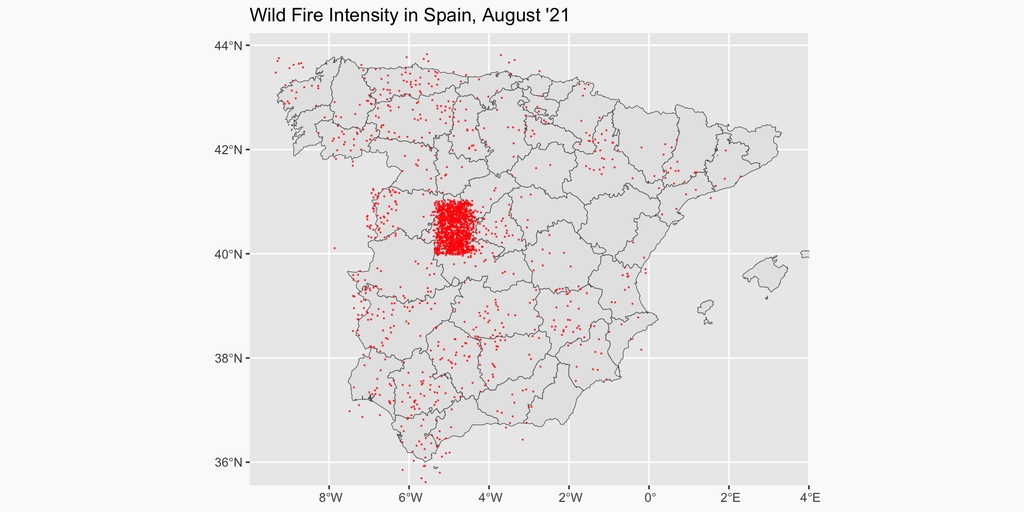

```r
error<-0.05
ggplot() +
  geom_sf(data = esp2b) +
  #high jitter
  geom_sf(data = st_jitter(fires_augb, 0.5),
          size=0.05, color = "red", alpha = 0.7) +
  coord_sf(xlim = c(min_lon_x - error, max_lon_x + error),
           ylim = c(min_lat_y - error, max_lat_y + error)) +
  ggtitle("Wild Fire Intensity in Spain, August '21") +
  guides(
    color = guide_legend(title.position = "top"),
    size = guide_legend(title.position = "top")
  )
```

## Original Data Comparison

And this is how the original data compares to the counts

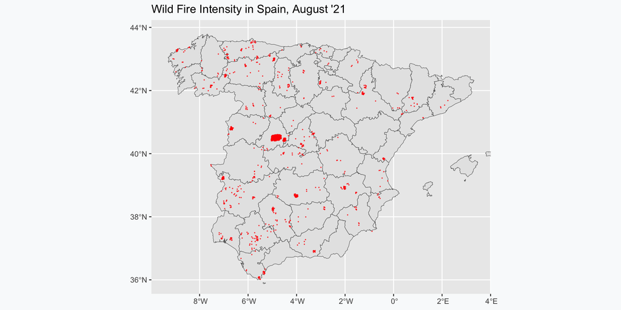

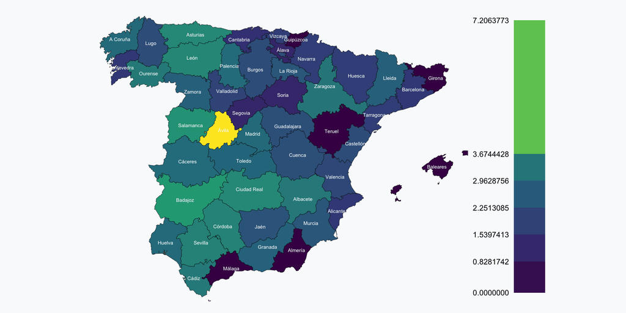

## Spatial Join: Count by Polygon - Step 1

And this is how we produce this graph:

Step 1:

```r
library(dplyr)
library(gridExtra)
#Step1: Selecting only one variable
esp2b<-subset(esp2, select = c("NAME_2"))
#Step2: Selecting only bright_ti5.
#This represents I-5 Channel brightness temperature of the fire pixel measured in Kelvin.
fires_augb<-subset(fires_aug, select = c("bright_ti5"))
#Step3: Adding a variable fire_no = 1 to help count fires
fires_augb$fire_no<-1
#Step4: Performing the spatial join
xjoin<-st_join(fires_augb, esp2b)
```

Let us have a look at what `xtjoin` looks like

```r
head(xjoin, n=5)
```

```
     bright_ti5     NAME_2 fire_no
5826     291.07   Valencia       1
5829     289.18       Jaén       1
5831     310.31     Toledo       1
5832     310.22     Cuenca       1
5837     298.88 Las Palmas       1
```

## A barplot for `xtjoin` - Step 1

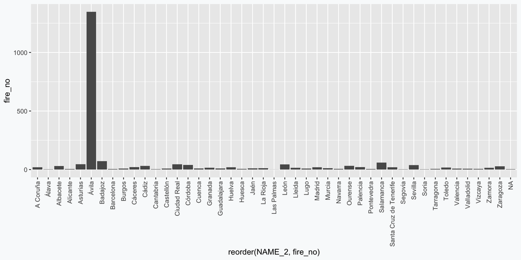

## A barplot for `xtjoin` - Step 1

**Question**

What does every row in `xtjoin` represent?

In other words, what is the unit of analysis?

**Answer**

The unit is fire (i.e. the invidual event). The unit is NOT the district.

This is why Avila appears over 1,000 times

Thus, we need to count how many fires we have per district.

## Spatial Join: Count by Polygon - Step 1

```r
#Step4: Dropping the geometry from the object (i.e. turning it into a regular dataframe)
#We need to drop the geometry to aggregate by group
xjoin<-st_drop_geometry(xjoin)
#Step5: Summing by polygons
sum_per_province <- xjoin %>%
  group_by(NAME_2) %>%
  summarize(sum_fires = sum(fire_no, na.rm = TRUE))
#Step6: Performing a left join to the shapefiles
esp1c<-left_join(esp2b, sum_per_province, by = c("NAME_2"="NAME_2"))
#Step7: Replacing NAs with 0
esp1c$sum_fires[is.na(esp1c$sum_fires)]<-0
#Step8: Calculating logs to eliminate extreme values
esp1c$log_fires<-log(esp1c$sum_fires+1)
```

## Spatial Join: Count by Polygon - Step 2

And this is how we produce this graph:

Step 2:

```r
#Step9: Calculating SD and Mean
fires_sd <- sd(esp1c$log_fires, na.rm=T)
fires_mean <- mean(esp1c$log_fires, na.rm=T)

#Step10: Creating different steps
step1<-min(esp1c$log_fires, na.rm=T)
step2<-fires_mean - fires_sd
step3<-fires_mean - 0.5*fires_sd
step4<-fires_mean
step5<-fires_mean + 0.5*fires_sd
step6<-fires_mean + fires_sd
step7<-max(esp1c$log_fires, na.rm=T)

#Step11: Putting all the steps in a list
clint <- c(step1,
           step2,
           step3,
           step4,
           step5,
           step6,
           step7)
clint
```

```
[1] 0.0000000 0.8281742 1.5397413 2.2513085 2.9628756 3.6744428 7.2063773
```

## Spatial Join: Count by Polygon - Step 3

And this is how we produce this graph:

Step 3:

```r
#Step1: Reading Spain borders
sf_use_s2(FALSE)
esp0 <- st_read(dsn="./data/gadm41_ESP_shp/gadm41_ESP_0.shp", quiet = TRUE)
esp0<-st_simplify(esp0, dTolerance=0.05)
#Step2: Simplifying country polygon
esp0b = st_cast(esp0,"POLYGON")
#Step3: Calculating polygon area
esp0b$area<-st_area(esp0b)
#Step4: Turning the units into square km
esp0b$area2<-units::set_units(esp0b$area, km^2)
#Step5: Only choosing the largest polygon
esp0c<-subset(esp0b, area2==max(esp0b$area2))

#Step6: Making a box object around the polygon
bbox <- st_bbox(esp0c)

#Step7: Extracting min and max latitudes and longitudes
min_lat_y <- bbox["ymin"]
max_lat_y <- bbox["ymax"]
min_lon_x <- bbox["xmin"]
max_lon_x <- bbox["xmax"]
```

## Spatial Join: Count by Polygon - Step 4

And this is how we produce this graph:

Step 4:

```r
#The Map
p1<-ggplot(esp1c, aes(fill=log_fires)) +
  geom_sf() +
  theme_void() +
  scale_fill_viridis_c(option = "viridis",
                       breaks = clint,
                       guide = guide_coloursteps(even.steps = FALSE,
                                                 title = NULL,
                                                 barheight = unit(5.3, "cm"),
                                                 barwidth = unit(0.64, "cm"),
                                                 label.position = "left"))+
  geom_sf_text(aes(label = NAME_2), colour = "white", size=1.5)+
  coord_sf(xlim = c(min_lon_x - error, max_lon_x + error),
           ylim = c(min_lat_y - error, max_lat_y + error))
p1
```

## Spatial Join: Count by Polygon - Step 5

And this is how we produce this graph:

Step 5:

```r
#The Histogram
p2<- ggplot(esp1c, aes(log_fires)) +
  geom_histogram(aes(y = after_stat(density)), bins = 10,
                 fill = "grey70",
                 col = "white")+
  coord_flip() +
  geom_density(colour = "blue")+
  scale_x_continuous(breaks = clint,
                     labels = c("Min", "-1SD" , "-0.5*SD", "Mean", "0.5*SD", "1SD", "Max"),
                     position = "top", limits = range(clint)) +
 scale_y_continuous(labels = NULL, breaks = NULL) +
  ylab(NULL) +xlab(NULL) +
   theme(plot.margin = margin(0.1,0,0,0.1, "in"),
         axis.text = element_text(colour = "grey"),
         panel.background = element_blank())
```

## Spatial Join: Count by Polygon - Step 6

And this is how we produce this graph:

Step 6:

````markdown
```{r , fig.width = 6.5, fig.height=2.4}
library(gridExtra)
#Arranging the Map and Histogram together
#in grid.arrange there are 4 slots in a row. you need to indicate which slot will be taken
#by fig1 vs. fig2. In our case, fig1 takes the first 3 slots
#fig2 takes the 4th slot.
pic<-grid.arrange(p1,p2, layout_matrix=rbind(c(1,1,1,2)))
```
````

## Spatial Join: Count by Polygon - Step 6

And this is how we produce this graph:

Step 6:

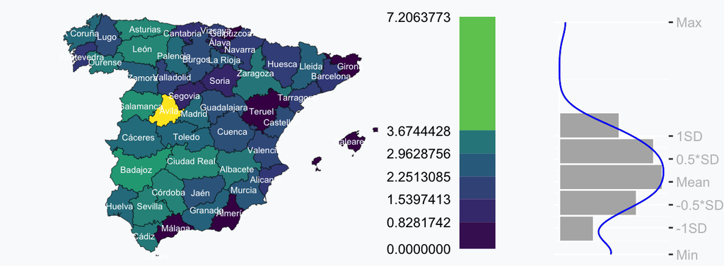

## Spatial Join: Count by Polygon - Step 6

To save the map that you made still look good, you should use the fillowing dimensions:

```r
ggsave("./figx.jpg", plot = pic, height = 6, width = 15, units = "cm", dpi = 300)
```

## Spatial Join: Count by Polygon

Thus, with the help of spatial join, we can count the number of fires by district.

We can further use a barplot to rank provinces.

```r
ggplot(esp1c,
  aes(x = reorder(NAME_2, -log_fires), y = log_fires)) +
  labs(x = "Province")+
  geom_bar(stat = "identity")+
  theme(
      panel.background = element_rect(fill = "white", color = "white"),
      #axis.line = element_line(color = "black"),
      panel.grid.major = element_line(color = "gray95", linetype = "solid"),
      panel.grid.minor = element_blank(),
      panel.border = element_rect(color = "black", fill = NA),
      axis.text = element_text(color = "black"),
      axis.title = element_text(color = "black"),
      strip.text = element_text(color = "black"),
      legend.text = element_text(color = "black"),
      legend.title = element_text(color = "black"),
      plot.title = element_text(color = "black"),
    axis.text.x = element_text(angle = 45, hjust = 1))
```

## Spatial Join: Count by Polygon

Thus, with the help of spatial join, we can count the number of fires by district.

We can further use a barplot to rank provinces.

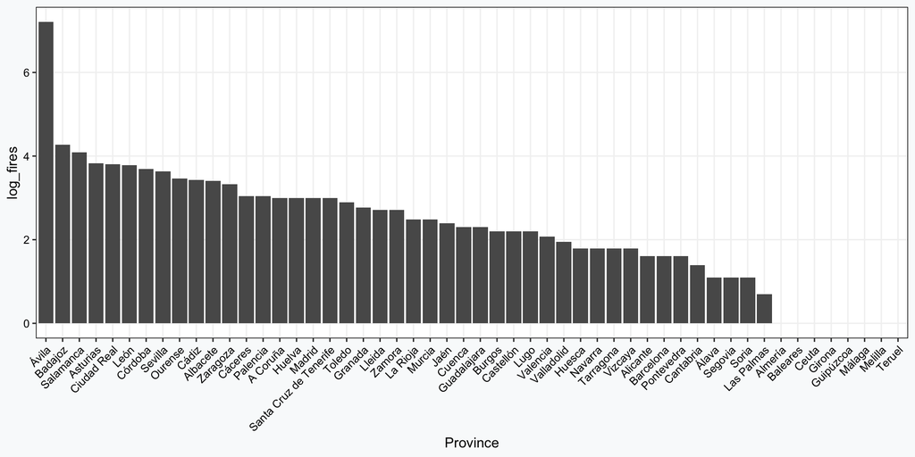

## Spatial Join: Count by Polygon

Notice also the substantial difference that logging the fire makes

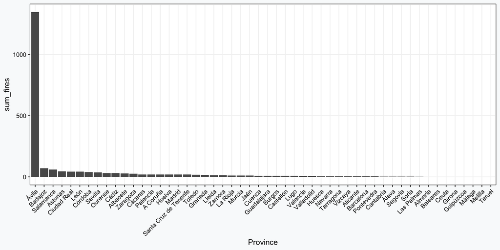

## Spatial Join: Share Attribute Table

We have thus far used `st_join` to count points per polygon

Another great use of spatial joins is to get one attribute table onto another one

Let’s say we have all the *settlements* in Spain.

We want to figure out what *county* they are part of

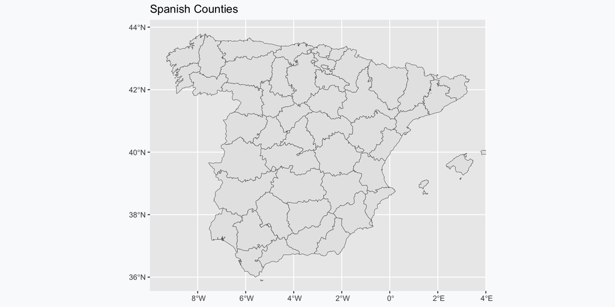

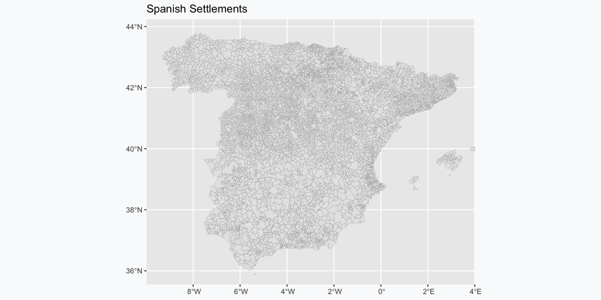

## Spatial Join: Share Attribute Table

We have thus far used `st_join` to count points per polygon

Another great use of spatial joins is to get one attribute table onto another one

Let’s say we have all the *settlements* in Spain.

We want to figure out what *county* they are part of

```r
head(esp2, n=5)
```

```
Simple feature collection with 5 features and 1 field
Geometry type: GEOMETRY
Dimension:     XY
Bounding box:  xmin: -7.522678 ymin: 35.99958 xmax: -1.630416 ymax: 38.72911
Geodetic CRS:  WGS 84
   NAME_2                       geometry
1 Almería POLYGON ((-2.575694 36.8043...
2   Cádiz POLYGON ((-6.229321 36.5273...
3 Córdoba MULTIPOLYGON (((-4.248001 3...
4 Granada POLYGON ((-3.419861 36.6937...
5  Huelva MULTIPOLYGON (((-7.121905 3...
```

```r
head(esp4, n=5)
```

```
Simple feature collection with 5 features and 1 field
Geometry type: POLYGON
Dimension:     XY
Bounding box:  xmin: -2.667413 ymin: 37.22897 xmax: -2.030814 ymax: 37.54468
Geodetic CRS:  WGS 84
               NAME_4                       geometry
1           Albánchez POLYGON ((-2.202082 37.3122...
2               Albox POLYGON ((-2.056954 37.4417...
3            Alcóntar POLYGON ((-2.60811 37.41111...
4            Arboleas POLYGON ((-2.131044 37.2996...
5 Armuña de Almanzora POLYGON ((-2.419804 37.3342...
```

## Spatial Join: Share Attribute Table

This is how we can think of a spatial join:

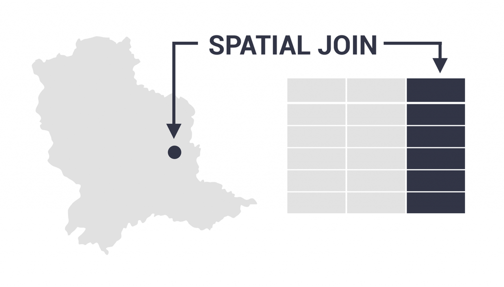